# Global GAM

# Prepare Data

```r
options(na.action = "na.exclude")

# variables to include:
c = c( "logchla", "Regions", "Date","Year", "Month",  "season","SAC","lagSAC",
       "EXPORT","OUT","lagOUT", "SJR", "lagSJR", "Index","lagIndex","DissAmmonia",
       "lagDissAmmonia", "TotPhos","lagTotPhos","DissNitrateNitrite",
       "lagDissNitrateNitrite","Temperature","lagTemperature","Secchi",
       "lagSecchi","Conductivity",  "lagConductivity","season_num", "DissOrthophos", "lagDissOrthophos", "clam_step")#, #"Biomass","Grazing_rate",#"Filtration_rate")


df <- read.csv("Data/regional_integrated_dataset3.csv" )

df$Date = as.Date(df$Date)

# 1979 is the start of the study period.
df <- subset(df,df$Date >= "1979-01-01")

# Changing categorical variables to factors
df$Regions = as.factor(df$Regions)
df$season = as.factor(df$season)
df$season_num = as.numeric(df$season)


#Replacing clam variables with a step function (pre/post potamocorbula introduction to the Bay in 1987)
df <- df%>%mutate(clam_step=if_else(Year>1987, "post clam", "pre clam"))
df$clam_step <- as.factor(df$clam_step)

# log transforming chl-a to achieve normal distribution of response variable.
df$logchla <- log(df$Chlorophyll)

# other option is using na.exclude on gams
# Dropping NAs from the dataset.
 df <- subset(df, select = c) #%>%
    #drop_na()

# z-score standardizing the dataset for more logical comparison of predictors. This facilitates comparison of effect sizes between variables.

df <- df %>% mutate(across(!c(Regions,season,Date,Month, Year, season_num, clam_step), ~as.vector(scale(.))))

df
```

|  | logchla | Regions | Date | Year | Month | season | SAC | lagSAC | EXPORT | OUT | lagOUT | SJR | lagSJR | Index | lagIndex | DissAmmonia | lagDissAmmonia | TotPhos | lagTotPhos | DissNitrateNitrite | lagDissNitrateNitrite | Temperature | lagTemperature | Secchi | lagSecchi | Conductivity | lagConductivity | season_num | DissOrthophos | … |
| --- | --- | --- | --- | --- | --- | --- | --- | --- | --- | --- | --- | --- | --- | --- | --- | --- | --- | --- | --- | --- | --- | --- | --- | --- | --- | --- | --- | --- | --- | --- |
| 30 | 0.0646041660 | Central | 1979-11-01 | 1979 | 11 | Autumn | -0.407839827 | -0.43295612 | -0.23458152 | -0.315357787 | -0.597035549 | -0.325243655 | -0.49025116 | 0.4018405 | -0.3779144 | -0.258069807 | -0.822067412 | 0.210404425 | 0.131030804 | 0.029768995 | -0.616258335 | -0.8463077628 | 1.66937243 | -0.1579445665 | -0.845829342 | -4.500120e-01 | -0.405288495 | 1 | 0.4657336560 | … |
| 31 | 0.1609540057 | Central | 1979-12-01 | 1979 | 12 | Autumn | -0.096558343 | -0.43295612 | -0.19607404 | -0.132991947 | -0.597035549 | -0.298079994 | -0.49025116 | 0.4018405 | -0.3779144 | -0.333101753 | -0.822067412 | 0.483349280 | 0.131030804 | -0.188984017 | -0.616258335 | -1.1189108847 | 1.66937243 | -0.4617382659 | -0.845829342 | -4.533737e-01 | -0.405288495 | 1 | 0.7534193878 | … |
| 32 | 0.4297984641 | Central | 1979-10-01 | 1979 | 10 | Autumn | -0.567305388 | -0.43295612 | 0.39205537 | -0.431680227 | -0.597035549 | -0.248638978 | -0.49025116 | 0.4018405 | -0.3779144 | -0.565700786 | -0.822067412 | NA | 0.131030804 | -0.328649402 | -0.616258335 | 0.4485570664 | 1.66937243 | -0.4336957706 | -0.845829342 | -4.293769e-01 | -0.405288495 | 1 | NA | … |
| 33 | 0.8908630518 | Central | 1980-11-01 | 1980 | 11 | Autumn | -0.671023385 | -0.39040402 | -0.03604136 | -0.461917561 | -0.480667147 | -0.169261892 | -0.22440697 | -0.5324684 | 0.4057637 | -0.570202703 | -0.739386373 | 0.101226484 | NA | -0.215234379 | -0.548088411 | -0.4312695096 | 1.53127807 | -0.3187215397 | -0.719836175 | -4.550116e-01 | -0.466683412 | 1 | -0.1836141386 | … |
| 34 | NA | Central | 1980-10-01 | 1980 | 10 | Autumn | -0.642330699 | -0.39040402 | 0.05775663 | -0.444388724 | -0.480667147 | -0.039841320 | -0.22440697 | -0.5324684 | 0.4057637 | -0.543191202 | -0.739386373 | NA | NA | -0.443074055 | -0.548088411 | 0.1815299174 | 1.53127807 | -0.3368216958 | -0.719836175 | -4.609456e-01 | -0.466683412 | 1 | NA | … |
| 35 | 0.3532204779 | Central | 1980-12-01 | 1980 | 12 | Autumn | -0.317417165 | -0.39040402 | 0.06558584 | -0.306986470 | -0.480667147 | -0.222736299 | -0.22440697 | -0.5324684 | 0.4057637 | 0.402211320 | -0.739386373 | 0.607415122 | NA | 0.047269236 | -0.548088411 | -1.4535312168 | 1.53127807 | -0.1364453201 | -0.719836175 | -4.462140e-01 | -0.466683412 | 1 | 0.6054667257 | … |
| 36 | 0.4595646959 | Central | 1981-10-01 | 1981 | 10 | Autumn | -0.730399625 | -0.51705067 | -0.20889517 | -0.500431547 | -0.601557651 | -0.477297108 | -0.54362861 | 1.6299779 | -0.5300207 | -0.552195036 | -0.860769175 | NA | 0.296494927 | -0.209176603 | -0.675238833 | 0.3758629006 | 1.54437961 | -0.1098049495 | -0.489729118 | -3.433675e-01 | -0.413938840 | 1 | NA | … |
| 37 | 0.1740497787 | Central | 1981-11-01 | 1981 | 11 | Autumn | 0.670797263 | -0.51705067 | -0.61137026 | 0.318423599 | -0.601557651 | -0.448378580 | -0.54362861 | 1.6299779 | -0.5300207 | 1.272581896 | -0.860769175 | 0.632228291 | 0.296494927 | 0.521121916 | -0.675238833 | -0.1976362431 | 1.54437961 | 0.1003862996 | -0.489729118 | -3.932858e-01 | -0.413938840 | 1 | 0.9589091962 | … |
| 38 | -0.6524981486 | Central | 1981-12-01 | 1981 | 12 | Autumn | 2.441356668 | -0.51705067 | -0.46275784 | 1.655930579 | -0.601557651 | -0.401638168 | -0.54362861 | 1.6299779 | -0.5300207 | 0.972454111 | -0.860769175 | 0.805920471 | 0.296494927 | 0.753336652 | -0.675238833 | -1.1325410408 | 1.54437961 | -0.4437109475 | -0.489729118 | -4.438812e-01 | -0.413938840 | 1 | 1.2465949280 | … |
| 39 | 0.0200755686 | Central | 1982-11-01 | 1982 | 11 | Autumn | 0.584697629 | -0.05914742 | -0.16319171 | 0.402252087 | -0.165557848 | 0.432839659 | 0.19515928 | 2.4652434 | 1.6358408 | -0.558197591 | -0.693061535 | -0.360298452 | NA | -0.471680218 | -0.419256263 | -0.7900833689 | 1.43062334 | -0.4336957706 | -0.675590582 | -4.714518e-01 | -0.474093167 | 1 | -0.3973235394 | … |

[output cut: 2665 more lines]

# Model Selection

## Choose Models With Best Combination of Flow Variables

```r
#options(na.action = "na.fail")
# OUT (no EXPORT, no step)
# m1 <- gam((logchla) ~ DissAmmonia +
#                DissNitrateNitrite +
#                Temperature +
#                Conductivity +
#                OUT +
#                s(Regions, bs='re') +
#                season +
#                (OUT*season) +
#                Grazing_rate +
#                lagOUT +
#                lagDissAmmonia +
#                lagDissNitrateNitrite,
#              data = df,
#              method = 'ML'
#              )
#
# # # SAC (no EXPORT, no step)
# m2 <- gam((logchla) ~ DissAmmonia +
#                DissNitrateNitrite +
#                Temperature +
#                Conductivity +
#                SAC +
#                s(Regions, bs='re') +
#                season +
#                (SAC*season) +
#                Grazing_rate +
#                lagSAC +
#                lagDissAmmonia +
#                lagDissNitrateNitrite,
#              data = df,
#              method = 'ML'
#              )
```

```r
# OUT + Step (no EXPORT)
m3 <- gam((logchla) ~ DissAmmonia +
               DissNitrateNitrite +
               Temperature +
               Conductivity +
               OUT +
               s(Regions, bs='re') +
               season +
               (OUT*season) +
               clam_step +
               lagOUT +
               lagDissAmmonia +
               lagDissNitrateNitrite,
             data = df,
             method = 'ML'
             )

# SAC + Step (no EXPORT)
m4 <- gam((logchla) ~ DissAmmonia +
               DissNitrateNitrite +
               Temperature +
               Conductivity +
               SAC +
               s(Regions, bs='re') +
               season +
               (SAC*season) +
               clam_step +
               lagSAC +
               lagDissAmmonia,
              # lagDissNitrateNitrite, # removing based on dredge
             data = df,
             method = 'ML'
             )

# OUT + EXPORT + Step
# m5 <- gam((logchla) ~ DissAmmonia +
#                DissNitrateNitrite +
#                Temperature +
#                Conductivity +
#                OUT +
#                EXPORT +
#                s(Regions, bs='re') +
#                season +
#                (OUT*season) +
#                clam_step +
#                lagOUT +
#                lagDissAmmonia +
#                lagDissNitrateNitrite,
#              data = df,
#              method = 'ML'
#              )

#SAC+ EXPORT + Step (best performing combo)
m6 <- gam((logchla) ~ DissAmmonia +
               DissNitrateNitrite +
               Temperature +
               Conductivity +
               SAC +
               EXPORT +
               s(Regions, bs='re') +
               season +
               # (SAC*season) + # removing based on dredge
               clam_step +
               lagSAC +
               lagDissAmmonia,
               #lagDissNitrateNitrite, # removing based on dredge
             data = df,
             method = 'ML'
             )

# m6 but with Season as a numeric smooth term with bs=cc (cyclic cubic spline)
# m7 <- gam((logchla) ~ DissAmmonia +
#                DissNitrateNitrite +
#                Temperature +
#                Conductivity +
#                SAC +
#                EXPORT +
#                s(Regions, bs='re') +
#                s(season_num, bs='cc', k=4) +
#                (SAC*season) +
#                clam_step +
#                lagSAC +
#                lagDissAmmonia +
#                lagDissNitrateNitrite,
#              data = df,
#              method = 'ML'
#              )
# SJR + OUT + EXPORT
# m8 <- gam((logchla) ~ DissAmmonia +
#                DissNitrateNitrite +
#                Temperature +
#                Conductivity +
#                SJR +
#                EXPORT +
#                s(Regions, bs='re') +
#                s(season_num, bs='cc', k=4) +
#                (SJR*season) +
#                clam_step +
#                lagSJR +
#                lagDissAmmonia +
#                lagDissNitrateNitrite,
#              data = df,
#              method = 'ML'
#              )
# SJR + OUT (no EXPORT)
# m9 <- gam((logchla) ~ DissAmmonia +
#                DissNitrateNitrite +
#                Temperature +
#                Conductivity +
#                SJR +
#                s(Regions, bs='re') +
#                s(season_num, bs='cc', k=4) +
#                (SJR*season) +
#                clam_step +
#                lagSJR +
#                lagDissAmmonia +
#                lagDissNitrateNitrite,
#              data = df,
#              method = 'ML'
#              )
```

## Compare with AIC

```r
AIC(m3, m4,m6)
```

|  | df | AIC |
| --- | --- | --- |
| m3 | 20.99758 | 5235.241 |
| m4 | 19.99419 | 5234.902 |
| m6 | 17.99419 | 5236.350 |

```r
BIC(m3, m4, m6)
```

|  | df | BIC |
| --- | --- | --- |
| m3 | 20.99758 | 5357.931 |
| m4 | 19.99419 | 5351.730 |
| m6 | 17.99419 | 5341.491 |

## Decisions/observations:

- remove month random effect
- keep season, try cyclic cubic spline bs=“cc”, set k=4 (m7)
  - season cyclic cubic spline removed after seeing it is insignificant in the models
- add region as a random effect
- models performed better with clam data as a step function

# Reduce variables in top models:

Dredging the top models to determine which variables to remove.

## m1

```r
# OUT (no EXPORT, no step)
# df <- subset(df, select = c)%>%
#    drop_na()
# options(na.action = "na.fail")
#m.1.dredge <- dredge(m1)
#m.1.dredge
```

## m2

```r
# # SAC (no EXPORT, no step)
# m.2.dredge <- dredge(m2)
# head(m.2.dredge, 3)
```

## m.3 - active

```r
# OUT + Step (no EXPORT)
#m.3.dredge <- dredge(m3)
# head(m.3.dredge, 3)
```

Global model call: gam(formula = (logchla) ~ DissAmmonia + DissNitrateNitrite + Temperature + Conductivity + OUT + s(Regions, bs = “re”) + season + (OUT * season) + clam_step + lagOUT + lagDissAmmonia + lagDissNitrateNitrite, data = df, method = “ML”) — Model selection table (Int) clm_stp Cnd DsA DNN lDA lDN OUT s(Rgn,“re”) 4032 -0.3008 + -0.06939 -0.03112 0.07865 0.10820 -0.03881 -0.08777 + 4000 -0.2931 + -0.07331 -0.02951 0.07022 0.10270 -0.08830 + 3996 -0.2982 + -0.07408 0.06258 0.09478 -0.08383 + ssn Tmp OUT:ssn df logLik AICc delta weight 4032 + 0.3048 + 19 -1795.546 3631.5 0.00 0.391 4000 + 0.3031 + 18 -1796.595 3631.6 0.05 0.382 3996 + 0.3102 + 17 -1798.133 3632.6 1.09 0.227 Models ranked by AICc(x)

## m.4 - active

```r
# SAC + Step (no EXPORT)
# m.4.dredge <- dredge(m4)
# head(m.4.dredge, 3)
```

Global model call: gam(formula = (logchla) ~ DissAmmonia + DissNitrateNitrite + Temperature + Conductivity + SAC + s(Regions, bs = “re”) + season + (SAC * season) + clam_step + lagSAC + lagDissAmmonia + lagDissNitrateNitrite, data = df, method = “ML”) — Model selection table (Int) clm_stp Cnd DsA DNN lDA lDN s(Rgn,“re”) SAC 4000 -0.2851 + -0.07562 -0.03230 0.06620 0.1078 + -0.05475 1984 -0.3065 + -0.07300 -0.03363 0.07382 0.1098 -0.04205 + -0.06866 4032 -0.2917 + -0.07216 -0.03369 0.07389 0.1126 -0.03481 + -0.05380 ssn Tmp SAC:ssn df logLik AICc delta weight 4000 + 0.2971 + 18 -1796.554 3631.5 0.00 0.362 1984 + 0.2817 16 -1798.675 3631.7 0.17 0.332 4032 + 0.2988 + 19 -1795.696 3631.8 0.33 0.306 Models ranked by AICc(x)

## m5

```r
# OUT + EXPORT + Step
#m.5.dredge <- dredge(m5)
#m.5.dredge
```

## m.6 -active

```r
# SAC+ EXPORT + Step (best performing combo)
# m.6.dredge <- dredge(m6)
# head(m.6.dredge, 3)
```

Global model call: gam(formula = (logchla) ~ DissAmmonia + DissNitrateNitrite + Temperature + Conductivity + SAC + EXPORT + s(Regions, bs = “re”) + season + (SAC * season) + clam_step + lagSAC + lagDissAmmonia + lagDissNitrateNitrite, data = df, method = “ML”) — Model selection table (Int) clm_stp Cnd DsA DNN EXP lDA lDN lSA 4032 -0.2813 + -0.07495 -0.02849 0.07064 -0.04236 0.1118 0.04141 4096 -0.2891 + -0.07215 -0.02976 0.07762 -0.04208 0.1160 -0.03312 0.03720 8000 -0.2828 + -0.07825 -0.02835 0.06788 -0.03971 0.1106  
s(Rgn,“re”) SAC ssn Tmp SAC:ssn df logLik AICc delta weight 4032 + -0.07462 + 0.2805 17 -1795.397 3627.1 0.00 0.398 4096 + -0.07332 + 0.2824 18 -1794.624 3627.6 0.50 0.310 8000 + -0.05055 + 0.2955 + 19 -1793.662 3627.8 0.61 0.293 Models ranked by AICc(x)

## m7

```r
# m6 but with as a numeric smooth term with bs=cc (cyclic cubic spline)
# m.7.dredge <- dredge(m7)
# head(m.7.dredge, 3)
```

## m8

```r
# SJR+EXPORT+ Step
# m.8.dredge <- dredge(m8)
# head(m.7.dredge, 3)
```

# Compare top models with AIC/BIC

```r
# #top.m1 <- get.models(m.1.dredge, 1)[[1]]
# #top.m2 <- get.models(m.2.dredge, 1)[[1]]
# top.m3 <- get.models(m.3.dredge, 1)[[1]]
# top.m4 <- get.models(m.4.dredge, 1)[[1]]
# #top.m5 <- get.models(m.5.dredge, 1)[[1]]
# top.m6 <- get.models(m.6.dredge, 1)[[1]]
#top.m7 <- get.models(m.7.dredge, 1)[[1]]
#top.m8 <- get.models(m.8.dredge, 1)[[1]]
```

compare the top dredged models with AIC and BIC

```r
# AIC(top.m3, top.m4, top.m6)
```

```r
# BIC(top.m3, top.m4, top.m6)
```

# Remove Season

The interaction with Sac:season was not significant in m6 but was in m3 and m4

```r
# OUT + Step (no EXPORT)
m3.no.season <- gam((logchla) ~ DissAmmonia +
               DissNitrateNitrite +
               Temperature +
               Conductivity +
               OUT +
               s(Regions, bs='re') +
               clam_step +
               lagOUT +
               lagDissAmmonia +
               lagDissNitrateNitrite,
             data = df,
             method = 'ML'
             )

# SAC + Step (no EXPORT)
m4.no.season <- gam((logchla) ~ DissAmmonia +
               DissNitrateNitrite +
               Temperature +
               Conductivity +
               SAC +
               s(Regions, bs='re') +
               clam_step +
               lagSAC +
               lagDissAmmonia +
               lagDissNitrateNitrite,
             data = df,
             method = 'ML'
             )

#SAC+ EXPORT + Step (best performing combo)
m6.no.season <- gam((logchla) ~ DissAmmonia +
               DissNitrateNitrite +
               Temperature +
               Conductivity +
               SAC +
               EXPORT +
               s(Regions, bs='re') +
               clam_step +
               lagSAC +
               lagDissAmmonia +
               lagDissNitrateNitrite,
             data = df,
             method = 'ML'
             )
```

## Check AIC of models so far

```r
AIC(m3.no.season, m4.no.season, m6.no.season, m3, m4, m6)
```

|  | df | AIC |
| --- | --- | --- |
| m3.no.season | 14.99619 | 5297.520 |
| m4.no.season | 14.99603 | 5291.983 |
| m6.no.season | 15.99609 | 5285.186 |
| m3 | 20.99758 | 5235.241 |
| m4 | 19.99419 | 5234.902 |
| m6 | 17.99419 | 5236.350 |

```r
BIC(m3.no.season, m4.no.season, m6.no.season, m3, m4, m6)
```

|  | df | BIC |
| --- | --- | --- |
| m3.no.season | 14.99619 | 5385.144 |
| m4.no.season | 14.99603 | 5379.606 |
| m6.no.season | 15.99609 | 5378.653 |
| m3 | 20.99758 | 5357.931 |
| m4 | 19.99419 | 5351.730 |
| m6 | 17.99419 | 5341.491 |

## m3 no season = active

```r
# m3.no.season.dredge <- dredge(m3.no.season)
# head(m3.no.season.dredge, 3)
```

Global model call: gam(formula = (logchla) ~ DissAmmonia + DissNitrateNitrite + Temperature + Conductivity + OUT + s(Regions, bs = “re”) + clam_step + lagOUT + lagDissAmmonia + lagDissNitrateNitrite, data = df, method = “ML”) — Model selection table (Int) clm_stp Cnd DsA DNN lDA lDN lOU OUT 1024 -0.0662 + -0.1052 -0.04578 0.06000 0.1497 0.09286 0.08020 -0.05812 1016 -0.0630 + -0.1061 -0.03797 0.1462 0.10920 0.07587 -0.06411 1020 -0.0666 + -0.1081 0.04648 0.1376 0.10250 0.08302 -0.05307 s(Rgn,“re”) Tmp df logLik AICc delta weight 1024 + 0.2986 14 -1847.929 3726.1 0.00 0.763 1016 + 0.2853 13 -1850.386 3729.0 2.88 0.181 1020 + 0.3087 13 -1851.550 3731.3 5.21 0.056 Models ranked by AICc(x)

## m4 no season - active

```r
# m4.no.season.dredge <- dredge(m4.no.season)
# head(m4.no.season.dredge, 3)
```

Global model call: gam(formula = (logchla) ~ DissAmmonia + DissNitrateNitrite + Temperature + Conductivity + SAC + s(Regions, bs = “re”) + clam_step + lagSAC + lagDissAmmonia + lagDissNitrateNitrite, data = df, method = “ML”) — Model selection table (Int) clm_stp Cnd DsA DNN lDA lDN lSA s(Rgn,“re”) 1024 -0.06646 + -0.1095 -0.05020 0.06015 0.1537 0.09403 0.08867 + 1016 -0.06300 + -0.1112 -0.04238 0.1503 0.11010 0.08414 + 1020 -0.06710 + -0.1121 0.04537 0.1402 0.10460 0.08995 + SAC Tmp df logLik AICc delta weight 1024 -0.07314 0.2914 14 -1846.089 3722.4 0.00 0.788 1016 -0.07904 0.2780 13 -1848.559 3725.3 2.90 0.185 1020 -0.06614 0.3034 13 -1850.452 3729.1 6.69 0.028 Models ranked by AICc(x)

## m6 no season - active

```r
# m6.no.season.dredge <- dredge(m6.no.season)
# head(m6.no.season.dredge, 3)
```

Global model call: gam(formula = (logchla) ~ DissAmmonia + DissNitrateNitrite + Temperature + Conductivity + SAC + EXPORT + s(Regions, bs = “re”) + clam_step + lagSAC + lagDissAmmonia + lagDissNitrateNitrite, data = df, method = “ML”) — Model selection table (Int) clm_stp Cnd DsA DNN EXP lDA lDN lSA 2048 -0.06292 + -0.1091 -0.03903 0.07505 -0.07952 0.1537 0.06009 0.09201 1984 -0.06246 + -0.1069 -0.04251 0.08893 -0.08610 0.1671 0.09169 2044 -0.06323 + -0.1111 0.06448 -0.08353 0.1433 0.06652 0.09316 s(Rgn,“re”) SAC Tmp df logLik AICc delta weight 2048 + -0.05762 0.3034 15 -1830.625 3693.5 0.00 0.620 1984 + -0.05493 0.3059 14 -1832.536 3695.3 1.78 0.255 2044 + -0.05147 0.3133 14 -1833.244 3696.7 3.21 0.125 Models ranked by AICc(x)

# Add Dissolved Orthophosphate

```r
# OUT (no EXPORT)
m3.po4 <- gam((logchla) ~ DissAmmonia +
               DissNitrateNitrite +
               Temperature +
               Conductivity +
               OUT +
               s(Regions, bs='re') +
               season +
               (OUT*season) +
               clam_step +
               lagOUT +
               lagDissAmmonia +
               lagDissNitrateNitrite+
               DissOrthophos +
               lagDissOrthophos,
             data = df,
             method = 'ML'
             )

# SAC  (no EXPORT)
m4.po4 <- gam((logchla) ~ DissAmmonia +
               DissNitrateNitrite +
               Temperature +
               Conductivity +
               SAC +
               s(Regions, bs='re') +
               season +
               (SAC*season) +
               clam_step +
               lagSAC +
               lagDissAmmonia +
               lagDissNitrateNitrite+
               DissOrthophos +
               lagDissOrthophos,
             data = df,
             method = 'ML'
             )

#SAC+ EXPORT
m6.po4 <- gam((logchla) ~ DissAmmonia +
               DissNitrateNitrite +
               Temperature +
               Conductivity +
               SAC +
               EXPORT +
               s(Regions, bs='re') +
               season +
               (SAC*season) +
               clam_step +
               lagSAC +
               lagDissAmmonia +
               lagDissNitrateNitrite+
               DissOrthophos +
               lagDissOrthophos,
             data = df,
             method = 'ML'
             )
# OUT (no EXPORT)
m3.no.season.po4 <- gam((logchla) ~ DissAmmonia +
               DissNitrateNitrite +
               Temperature +
               Conductivity +
               OUT +
               s(Regions, bs='re') +
               clam_step +
               lagOUT +
               lagDissAmmonia +
               lagDissNitrateNitrite+
               DissOrthophos +
               lagDissOrthophos,
             data = df,
             method = 'ML'
             )

# SAC + Step (no EXPORT)
m4.no.season.po4 <- gam((logchla) ~ DissAmmonia +
               DissNitrateNitrite +
               Temperature +
               Conductivity +
               SAC +
               s(Regions, bs='re') +
               clam_step +
               lagSAC +
               lagDissAmmonia +
               lagDissNitrateNitrite+
               DissOrthophos +
               lagDissOrthophos,
             data = df,
             method = 'ML'
             )

#SAC+ EXPORT + Step (best performing combo)
m6.no.season.po4 <- gam((logchla) ~ DissAmmonia +
               DissNitrateNitrite +
               Temperature +
               Conductivity +
               SAC +
               EXPORT +
               s(Regions, bs='re') +
               clam_step +
               lagSAC +
               lagDissAmmonia +
               lagDissNitrateNitrite +
               DissOrthophos +
               lagDissOrthophos,
             data = df,
             method = 'ML'
             )
```

# AIC/BIC of models before smoothing predictors

```r
AIC(m3,m4,m6,m3.no.season,m4.no.season,m6.no.season,m3.po4,m4.po4,m6.po4,m3.no.season.po4,m4.no.season.po4,m6.no.season.po4)
```

|  | df | AIC |
| --- | --- | --- |
| m3 | 20.99758 | 5235.241 |
| m4 | 19.99419 | 5234.902 |
| m6 | 17.99419 | 5236.350 |
| m3.no.season | 14.99619 | 5297.520 |
| m4.no.season | 14.99603 | 5291.983 |
| m6.no.season | 15.99609 | 5285.186 |
| m3.po4 | 22.99500 | 4359.417 |
| m4.po4 | 22.99465 | 4362.158 |
| m6.po4 | 23.99454 | 4362.598 |
| m3.no.season.po4 | 16.99226 | 4425.603 |

[output cut: 2 more lines]

```r
BIC(m3,m4,m6,m3.no.season,m4.no.season,m6.no.season,m3.po4,m4.po4,m6.po4,m3.no.season.po4,m4.no.season.po4,m6.no.season.po4)
```

|  | df | BIC |
| --- | --- | --- |
| m3 | 20.99758 | 5357.931 |
| m4 | 19.99419 | 5351.730 |
| m6 | 17.99419 | 5341.491 |
| m3.no.season | 14.99619 | 5385.144 |
| m4.no.season | 14.99603 | 5379.606 |
| m6.no.season | 15.99609 | 5378.653 |
| m3.po4 | 22.99500 | 4490.505 |
| m4.po4 | 22.99465 | 4493.245 |
| m6.po4 | 23.99454 | 4499.385 |
| m3.no.season.po4 | 16.99226 | 4522.471 |

[output cut: 2 more lines]

# Shrink top models:

- EDF close to 0 it is effectively removed from the model
- linear terms have EDF close to 1

## m3

Notes: s(OUT) has an EDF close to 0

```r
# OUT + Step (no EXPORT)
m3.shrink <- gam((logchla) ~ s(DissAmmonia) +
               s(DissNitrateNitrite) +
               s(Temperature) +
               s(Conductivity) +
               s(OUT) +
               s(Regions, bs='re') +
               season +
               (OUT*season) +
               clam_step +
               s(lagOUT) +
               s(lagDissAmmonia) +
               s(lagDissNitrateNitrite),
             data = df,
             method = 'ML',
             select=TRUE)
summary(m3.shrink)
```

```
##
## Family: gaussian
## Link function: identity
##
## Formula:
## (logchla) ~ s(DissAmmonia) + s(DissNitrateNitrite) + s(Temperature) +
##     s(Conductivity) + s(OUT) + s(Regions, bs = "re") + season +
##     (OUT * season) + clam_step + s(lagOUT) + s(lagDissAmmonia) +
##     s(lagDissNitrateNitrite)
##
## Parametric coefficients:
##                    Estimate Std. Error t value Pr(>|t|)
## (Intercept)       -0.232938   0.206914  -1.126    0.260
## seasonSpring       0.303924   0.064991   4.676 3.08e-06 ***
## seasonSummer       0.116178   0.107309   1.083    0.279
## seasonWinter       0.246391   0.049629   4.965 7.34e-07 ***
## OUT               -0.081003   0.052741  -1.536    0.125
## clam_steppre clam  0.456936   0.035397  12.909  < 2e-16 ***
## seasonSpring:OUT   0.109392   0.067292   1.626    0.104
## seasonSummer:OUT   0.149931   0.189101   0.793    0.428
## seasonWinter:OUT  -0.003076   0.054008  -0.057    0.955
## ---
## Signif. codes:  0 '***' 0.001 '**' 0.01 '*' 0.05 '.' 0.1 ' ' 1
##
## Approximate significance of smooth terms:
##                               edf Ref.df      F p-value
## s(DissAmmonia)           4.224352      9  5.711 < 2e-16 ***
## s(DissNitrateNitrite)    3.425218      9  1.915 0.00200 **
## s(Temperature)           6.648418      9 26.837 < 2e-16 ***
## s(Conductivity)          8.323376      9 17.771 0.10983
## s(OUT)                   0.003594      8  0.001 0.07334 .
## s(Regions)               3.939023      4 91.451 < 2e-16 ***
## s(lagOUT)                6.618059      9  7.717 < 2e-16 ***
## s(lagDissAmmonia)        1.400248      9  5.865 < 2e-16 ***
## s(lagDissNitrateNitrite) 3.752333      9  2.164 0.00503 **
## ---
## Signif. codes:  0 '***' 0.001 '**' 0.01 '*' 0.05 '.' 0.1 ' ' 1
##
## R-sq.(adj) =  0.588   Deviance explained = 59.5%
## -ML = 2562.7  Scale est. = 0.413     n = 2548
```

## m4

Notes: S(SAC) has an EDF close to 0 raised conductivity k because EDF close to ref.df

```r
# SAC + Step (no EXPORT)
m4.shrink <- gam((logchla) ~ s(DissAmmonia) +
               s(DissNitrateNitrite) +
               s(Temperature) +
               s(Conductivity, k=12) +
               s(SAC) +
               s(Regions, bs='re') +
               season +
               (SAC*season) +
               clam_step +
               s(lagSAC) +
               s(lagDissAmmonia),
               #s(lagDissNitrateNitrite), # removed based on dredge
             data = df,
             method = 'ML',
             select=TRUE)
summary(m4.shrink)
```

```
##
## Family: gaussian
## Link function: identity
##
## Formula:
## (logchla) ~ s(DissAmmonia) + s(DissNitrateNitrite) + s(Temperature) +
##     s(Conductivity, k = 12) + s(SAC) + s(Regions, bs = "re") +
##     season + (SAC * season) + clam_step + s(lagSAC) + s(lagDissAmmonia)
##
## Parametric coefficients:
##                   Estimate Std. Error t value Pr(>|t|)
## (Intercept)       -0.31059    0.20884  -1.487  0.13709
## seasonSpring       0.43395    0.05758   7.536 6.73e-14 ***
## seasonSummer       0.22896    0.07789   2.940  0.00331 **
## seasonWinter       0.35179    0.04868   7.226 6.56e-13 ***
## SAC               -0.02599    0.03992  -0.651  0.51512
## clam_steppre clam  0.44351    0.03455  12.835  < 2e-16 ***
## seasonSpring:SAC   0.03206    0.05416   0.592  0.55395
## seasonSummer:SAC   0.12048    0.11345   1.062  0.28835
## seasonWinter:SAC  -0.06986    0.04350  -1.606  0.10839
## ---
## Signif. codes:  0 '***' 0.001 '**' 0.01 '*' 0.05 '.' 0.1 ' ' 1
##
## Approximate significance of smooth terms:
##                             edf Ref.df       F p-value
## s(DissAmmonia)        4.540e+00      9   8.284 < 2e-16 ***
## s(DissNitrateNitrite) 3.630e+00      9   4.918 0.00993 **
## s(Temperature)        6.589e+00      9  28.232 < 2e-16 ***
## s(Conductivity)       1.022e+01     11  22.307 0.05676 .
## s(SAC)                4.063e-05      8   0.000 0.42404
## s(Regions)            3.950e+00      4 119.427 < 2e-16 ***
## s(lagSAC)             4.687e+00      9   7.235 < 2e-16 ***
## s(lagDissAmmonia)     1.611e+00      9   6.884 < 2e-16 ***
## ---
## Signif. codes:  0 '***' 0.001 '**' 0.01 '*' 0.05 '.' 0.1 ' ' 1
##
## R-sq.(adj) =   0.59   Deviance explained = 59.7%
## -ML = 2550.6  Scale est. = 0.41073   n = 2548
```

s(Sac) insignificant

## m6

```r
m6.shrink <- gam((logchla) ~ s(DissAmmonia) +
               s(DissNitrateNitrite) +
               s(Temperature) +
               s(Conductivity, k=12) +
               s(SAC) +
               s(EXPORT) +
               s(Regions, bs='re') +
              # s(SAC*season) + #removed based on dredge
               season +
               clam_step +
               s(lagSAC) +
               s(lagDissAmmonia),
              # s(lagDissNitrateNitrite), # removed based on dredge
             data = df,
             method = 'ML',
              select=TRUE
             )


summary(m6.shrink)
```

```
##
## Family: gaussian
## Link function: identity
##
## Formula:
## (logchla) ~ s(DissAmmonia) + s(DissNitrateNitrite) + s(Temperature) +
##     s(Conductivity, k = 12) + s(SAC) + s(EXPORT) + s(Regions,
##     bs = "re") + season + clam_step + s(lagSAC) + s(lagDissAmmonia)
##
## Parametric coefficients:
##                   Estimate Std. Error t value Pr(>|t|)
## (Intercept)       -0.29818    0.20990  -1.421  0.15557
## seasonSpring       0.40354    0.05556   7.263 5.04e-13 ***
## seasonSummer       0.17875    0.06654   2.686  0.00727 **
## seasonWinter       0.31204    0.04852   6.431 1.51e-10 ***
## clam_steppre clam  0.42017    0.03477  12.083  < 2e-16 ***
## ---
## Signif. codes:  0 '***' 0.001 '**' 0.01 '*' 0.05 '.' 0.1 ' ' 1
##
## Approximate significance of smooth terms:
##                          edf Ref.df       F p-value
## s(DissAmmonia)         4.491      9   7.675 < 2e-16 ***
## s(DissNitrateNitrite)  3.645      9   4.442  0.0124 *
## s(Temperature)         6.572      9  27.668 < 2e-16 ***
## s(Conductivity)       10.238     11  24.072  0.0441 *
## s(SAC)                 3.837      9   2.366 9.1e-05 ***
## s(EXPORT)              1.271      9   0.447  0.0319 *
## s(Regions)             3.951      4 118.967 < 2e-16 ***
## s(lagSAC)              4.779      9   7.034 < 2e-16 ***
## s(lagDissAmmonia)      2.636      9   7.305 < 2e-16 ***
## ---
## Signif. codes:  0 '***' 0.001 '**' 0.01 '*' 0.05 '.' 0.1 ' ' 1
##
## R-sq.(adj) =  0.592   Deviance explained = 59.9%
## -ML = 2555.3  Scale est. = 0.4091    n = 2548
```

## m3.no.season

```r
m3.no.season.shrink <- gam((logchla) ~ s(DissAmmonia) +
               s(DissNitrateNitrite) +
               s(Temperature) +
               s(Conductivity) +
               s(OUT) +
               s(Regions, bs='re') +
               clam_step +
               s(lagOUT) +
               s(lagDissAmmonia) +
               s(lagDissNitrateNitrite),
             data = df,
             method = 'ML',
             select=TRUE)
summary(m3.no.season.shrink)
```

```
##
## Family: gaussian
## Link function: identity
##
## Formula:
## (logchla) ~ s(DissAmmonia) + s(DissNitrateNitrite) + s(Temperature) +
##     s(Conductivity) + s(OUT) + s(Regions, bs = "re") + clam_step +
##     s(lagOUT) + s(lagDissAmmonia) + s(lagDissNitrateNitrite)
##
## Parametric coefficients:
##                   Estimate Std. Error t value Pr(>|t|)
## (Intercept)       -0.07917    0.18576  -0.426     0.67
## clam_steppre clam  0.43994    0.03492  12.600   <2e-16 ***
## ---
## Signif. codes:  0 '***' 0.001 '**' 0.01 '*' 0.05 '.' 0.1 ' ' 1
##
## Approximate significance of smooth terms:
##                            edf Ref.df      F  p-value
## s(DissAmmonia)           4.576      9  7.172  < 2e-16 ***
## s(DissNitrateNitrite)    3.834      9  1.524   0.0125 *
## s(Temperature)           6.775      9 35.479  < 2e-16 ***
## s(Conductivity)          8.417      9 19.585   0.1043
## s(OUT)                   6.690      9  4.793  < 2e-16 ***
## s(Regions)               3.926      4 84.118  < 2e-16 ***
## s(lagOUT)                6.674      9 10.026  < 2e-16 ***
## s(lagDissAmmonia)        3.074      9 10.561  < 2e-16 ***
## s(lagDissNitrateNitrite) 5.341      9  6.311 4.71e-07 ***
## ---
## Signif. codes:  0 '***' 0.001 '**' 0.01 '*' 0.05 '.' 0.1 ' ' 1
##
## R-sq.(adj) =  0.589   Deviance explained = 59.8%
## -ML = 2579.1  Scale est. = 0.41121   n = 2548
```

## m4.no.season

```r
# SAC + Step (no EXPORT)
m4.no.season.shrink <- gam((logchla) ~ s(DissAmmonia) +
               s(DissNitrateNitrite) +
               s(Temperature) +
               s(Conductivity, k=12) +
               s(SAC) +
               s(Regions, bs='re') +
               clam_step +
               s(lagSAC) +
               s(lagDissAmmonia) +
               s(lagDissNitrateNitrite),
             data = df,
             method = 'ML',
             select=TRUE)
summary(m4.no.season.shrink)
```

```
##
## Family: gaussian
## Link function: identity
##
## Formula:
## (logchla) ~ s(DissAmmonia) + s(DissNitrateNitrite) + s(Temperature) +
##     s(Conductivity, k = 12) + s(SAC) + s(Regions, bs = "re") +
##     clam_step + s(lagSAC) + s(lagDissAmmonia) + s(lagDissNitrateNitrite)
##
## Parametric coefficients:
##                   Estimate Std. Error t value Pr(>|t|)
## (Intercept)       -0.08095    0.17348  -0.467    0.641
## clam_steppre clam  0.44947    0.03468  12.959   <2e-16 ***
## ---
## Signif. codes:  0 '***' 0.001 '**' 0.01 '*' 0.05 '.' 0.1 ' ' 1
##
## Approximate significance of smooth terms:
##                             edf Ref.df      F  p-value
## s(DissAmmonia)            4.828      9  8.846  < 2e-16 ***
## s(DissNitrateNitrite)     4.035      9  1.480   0.0162 *
## s(Temperature)            6.718      9 38.914  < 2e-16 ***
## s(Conductivity)          10.165     11 14.555   0.1139
## s(SAC)                    4.170      9  2.699 3.49e-05 ***
## s(Regions)                3.914      4 80.521  < 2e-16 ***
## s(lagSAC)                 3.795      9 10.025  < 2e-16 ***
## s(lagDissAmmonia)         3.474      9 11.808  < 2e-16 ***
## s(lagDissNitrateNitrite)  5.922      9  9.808  < 2e-16 ***
## ---
## Signif. codes:  0 '***' 0.001 '**' 0.01 '*' 0.05 '.' 0.1 ' ' 1
##
## R-sq.(adj) =  0.587   Deviance explained = 59.5%
## -ML = 2578.3  Scale est. = 0.41322   n = 2548
```

## m6.no.season

Notes: EDF of s(EXPORT) is close to 1

```r
# SAC + EXPORT
m6.no.season.shrink <- gam((logchla) ~ s(DissAmmonia) +
               s(DissNitrateNitrite) +
               s(Temperature) +
               s(Conductivity, k=12) +
               s(SAC) +
               s(EXPORT) +
               s(Regions, bs='re') +
               clam_step +
               s(lagSAC) +
               s(lagDissAmmonia) +
               s(lagDissNitrateNitrite),
             data = df,
             method = 'ML',
             select=TRUE)
summary(m6.no.season.shrink)
```

```
##
## Family: gaussian
## Link function: identity
##
## Formula:
## (logchla) ~ s(DissAmmonia) + s(DissNitrateNitrite) + s(Temperature) +
##     s(Conductivity, k = 12) + s(SAC) + s(EXPORT) + s(Regions,
##     bs = "re") + clam_step + s(lagSAC) + s(lagDissAmmonia) +
##     s(lagDissNitrateNitrite)
##
## Parametric coefficients:
##                   Estimate Std. Error t value Pr(>|t|)
## (Intercept)       -0.07790    0.17928  -0.435    0.664
## clam_steppre clam  0.43354    0.03476  12.471   <2e-16 ***
## ---
## Signif. codes:  0 '***' 0.001 '**' 0.01 '*' 0.05 '.' 0.1 ' ' 1
##
## Approximate significance of smooth terms:
##                              edf Ref.df      F  p-value
## s(DissAmmonia)            4.6417      9  7.740  < 2e-16 ***
## s(DissNitrateNitrite)     4.0975      9  1.628   0.0103 *
## s(Temperature)            6.6277      9 39.899  < 2e-16 ***
## s(Conductivity)          10.1923     11 15.528   0.1058
## s(SAC)                    4.9796      9  3.900 6.26e-07 ***
## s(EXPORT)                 0.9364      9  1.666 4.97e-05 ***
## s(Regions)                3.9196      4 82.654  < 2e-16 ***
## s(lagSAC)                 3.4817      9  9.333  < 2e-16 ***
## s(lagDissAmmonia)         3.3682      9 11.616  < 2e-16 ***
## s(lagDissNitrateNitrite)  5.5885      9  7.878  < 2e-16 ***
## ---
## Signif. codes:  0 '***' 0.001 '**' 0.01 '*' 0.05 '.' 0.1 ' ' 1
##
## R-sq.(adj) =   0.59   Deviance explained = 59.7%
## -ML = 2573.1  Scale est. = 0.41103   n = 2548
```

## m3.po4

```r
# OUT  (no EXPORT)
m3.po4.shrink <- gam((logchla) ~ s(DissAmmonia) +
               s(DissNitrateNitrite) +
               s(Temperature) +
               s(Conductivity) +
               s(OUT) +
               s(Regions, bs='re') +
               season +
               (OUT*season) +
               clam_step +
               s(lagOUT) +
               s(lagDissAmmonia) +
               s(lagDissNitrateNitrite)+
               s(DissOrthophos)+
               s(lagDissOrthophos),
             data = df,
             method = 'ML',
             select=TRUE)
summary(m3.po4.shrink)
```

```
##
## Family: gaussian
## Link function: identity
##
## Formula:
## (logchla) ~ s(DissAmmonia) + s(DissNitrateNitrite) + s(Temperature) +
##     s(Conductivity) + s(OUT) + s(Regions, bs = "re") + season +
##     (OUT * season) + clam_step + s(lagOUT) + s(lagDissAmmonia) +
##     s(lagDissNitrateNitrite) + s(DissOrthophos) + s(lagDissOrthophos)
##
## Parametric coefficients:
##                   Estimate Std. Error t value Pr(>|t|)
## (Intercept)       -0.24548    0.18761  -1.308   0.1909
## seasonSpring       0.31035    0.06741   4.604 4.39e-06 ***
## seasonSummer       0.06982    0.10967   0.637   0.5244
## seasonWinter       0.22489    0.05036   4.465 8.40e-06 ***
## OUT               -0.05507    0.05975  -0.922   0.3568
## clam_steppre clam  0.37887    0.04342   8.725  < 2e-16 ***
## seasonSpring:OUT   0.11476    0.06863   1.672   0.0946 .
## seasonSummer:OUT   0.04515    0.19230   0.235   0.8144
## seasonWinter:OUT  -0.02139    0.05674  -0.377   0.7063
## ---
## Signif. codes:  0 '***' 0.001 '**' 0.01 '*' 0.05 '.' 0.1 ' ' 1
##
## Approximate significance of smooth terms:
##                             edf Ref.df      F  p-value
## s(DissAmmonia)           4.1116      9  2.171 0.000313 ***
## s(DissNitrateNitrite)    4.1084      9  5.980  < 2e-16 ***
## s(Temperature)           6.3128      9 27.793  < 2e-16 ***
## s(Conductivity)          7.8698      9  8.539 0.133783
## s(OUT)                   0.5291      8  0.222 0.041004 *
## s(Regions)               3.9220      4 81.123  < 2e-16 ***
## s(lagOUT)                6.8393      9  7.967  < 2e-16 ***
## s(lagDissAmmonia)        2.1247      9  4.986  < 2e-16 ***
## s(lagDissNitrateNitrite) 2.8465      9  1.156 0.028867 *
## s(DissOrthophos)         2.3960      9  1.963 9.49e-05 ***
## s(lagDissOrthophos)      5.0458      9  4.995  < 2e-16 ***
## ---
## Signif. codes:  0 '***' 0.001 '**' 0.01 '*' 0.05 '.' 0.1 ' ' 1
##
## R-sq.(adj) =  0.586   Deviance explained = 59.6%
## -ML = 2131.7  Scale est. = 0.37412   n = 2210
```

## m4.po4

Notes: EDF of s(SAC) is close to 0

```r
# SAC (no EXPORT)
m4.po4.shrink <- gam((logchla) ~ s(DissAmmonia) +
               s(DissNitrateNitrite) +
               s(Temperature) +
               s(Conductivity, k=12) +
               s(SAC) +
               s(Regions, bs='re') +
               season +
               (SAC*season) +
               clam_step +
               s(lagSAC) +
               s(lagDissAmmonia)+
               s(lagDissNitrateNitrite) +
               s(DissOrthophos)+
               s(lagDissOrthophos),
             data = df,
             method = 'ML',
             select=TRUE)
summary(m4.po4.shrink)
```

```
##
## Family: gaussian
## Link function: identity
##
## Formula:
## (logchla) ~ s(DissAmmonia) + s(DissNitrateNitrite) + s(Temperature) +
##     s(Conductivity, k = 12) + s(SAC) + s(Regions, bs = "re") +
##     season + (SAC * season) + clam_step + s(lagSAC) + s(lagDissAmmonia) +
##     s(lagDissNitrateNitrite) + s(DissOrthophos) + s(lagDissOrthophos)
##
## Parametric coefficients:
##                   Estimate Std. Error t value Pr(>|t|)
## (Intercept)       -0.31089    0.18483  -1.682  0.09271 .
## seasonSpring       0.41639    0.06539   6.368 2.34e-10 ***
## seasonSummer       0.21574    0.08150   2.647  0.00817 **
## seasonWinter       0.30309    0.05101   5.942 3.27e-09 ***
## SAC               -0.03173    0.04118  -0.770  0.44118
## clam_steppre clam  0.36583    0.04221   8.667  < 2e-16 ***
## seasonSpring:SAC   0.05217    0.05476   0.953  0.34084
## seasonSummer:SAC   0.10500    0.11732   0.895  0.37089
## seasonWinter:SAC  -0.07049    0.04458  -1.581  0.11402
## ---
## Signif. codes:  0 '***' 0.001 '**' 0.01 '*' 0.05 '.' 0.1 ' ' 1
##
## Approximate significance of smooth terms:
##                                edf Ref.df      F  p-value
## s(DissAmmonia)           4.4013554      9  2.996 1.19e-05 ***
## s(DissNitrateNitrite)    4.1225919      9  5.218  < 2e-16 ***
## s(Temperature)           6.3003175      9 27.021  < 2e-16 ***
## s(Conductivity)          9.6930753     11  9.395 0.083929 .
## s(SAC)                   0.0001161      8  0.000 0.166348
## s(Regions)               3.9190868      4 81.265  < 2e-16 ***
## s(lagSAC)                4.1785388      9  7.211  < 2e-16 ***
## s(lagDissAmmonia)        2.4218422      9  5.095  < 2e-16 ***
## s(lagDissNitrateNitrite) 3.0509094      9  1.017 0.054558 .
## s(DissOrthophos)         2.2703488      9  1.732 0.000234 ***
## s(lagDissOrthophos)      5.0089520      9  5.591  < 2e-16 ***
## ---
## Signif. codes:  0 '***' 0.001 '**' 0.01 '*' 0.05 '.' 0.1 ' ' 1
##
## R-sq.(adj) =  0.588   Deviance explained = 59.8%
## -ML = 2122.1  Scale est. = 0.37218   n = 2210
```

## m6.po4

```r
m6.po4.shrink <- gam((logchla) ~ s(DissAmmonia) +
               s(DissNitrateNitrite) +
               s(Temperature) +
               s(Conductivity, k=12) +
               s(SAC) +
               s(EXPORT) +
               s(Regions, bs='re') +
               season +
               (SAC:season) +
               clam_step +
               s(lagSAC) +
               s(lagDissAmmonia)+
               s(lagDissNitrateNitrite)+
               s(DissOrthophos)+
               s(lagDissOrthophos),
             data = df,
             method = 'ML',
              select=TRUE
             )


summary(m6.po4.shrink)
```

```
##
## Family: gaussian
## Link function: identity
##
## Formula:
## (logchla) ~ s(DissAmmonia) + s(DissNitrateNitrite) + s(Temperature) +
##     s(Conductivity, k = 12) + s(SAC) + s(EXPORT) + s(Regions,
##     bs = "re") + season + (SAC:season) + clam_step + s(lagSAC) +
##     s(lagDissAmmonia) + s(lagDissNitrateNitrite) + s(DissOrthophos) +
##     s(lagDissOrthophos)
##
## Parametric coefficients:
##                   Estimate Std. Error t value Pr(>|t|)
## (Intercept)       -0.30807    0.18708  -1.647  0.09976 .
## seasonSpring       0.39585    0.06693   5.914 3.87e-09 ***
## seasonSummer       0.25290    0.08282   3.054  0.00229 **
## seasonWinter       0.29898    0.05103   5.859 5.38e-09 ***
## clam_steppre clam  0.35123    0.04293   8.181 4.75e-16 ***
## seasonAutumn:SAC  -0.02848    0.04122  -0.691  0.48964
## seasonSpring:SAC   0.02571    0.03964   0.649  0.51669
## seasonSummer:SAC   0.12394    0.11540   1.074  0.28294
## seasonWinter:SAC  -0.09768    0.02284  -4.277 1.98e-05 ***
## ---
## Signif. codes:  0 '***' 0.001 '**' 0.01 '*' 0.05 '.' 0.1 ' ' 1
##
## Approximate significance of smooth terms:
##                                edf Ref.df      F  p-value
## s(DissAmmonia)           4.319e+00      9  2.762 2.97e-05 ***
## s(DissNitrateNitrite)    4.166e+00      9  5.204  < 2e-16 ***
## s(Temperature)           6.272e+00      9 26.863  < 2e-16 ***
## s(Conductivity)          9.707e+00     11  9.725 0.079014 .
## s(SAC)                   4.967e-05      8  0.000 0.280066
## s(EXPORT)                1.511e+00      9  0.624 0.017911 *
## s(Regions)               3.921e+00      4 82.404  < 2e-16 ***
## s(lagSAC)                4.301e+00      9  7.527  < 2e-16 ***
## s(lagDissAmmonia)        2.062e+00      9  5.268  < 2e-16 ***
## s(lagDissNitrateNitrite) 3.124e+00      9  1.087 0.045480 *
## s(DissOrthophos)         2.333e+00      9  1.721 0.000276 ***
## s(lagDissOrthophos)      5.007e+00      9  5.563  < 2e-16 ***
## ---
## Signif. codes:  0 '***' 0.001 '**' 0.01 '*' 0.05 '.' 0.1 ' ' 1
##
## R-sq.(adj) =  0.589   Deviance explained = 59.9%
## -ML = 2120.5  Scale est. = 0.37109   n = 2210
```

## m3.no.season.po4

```r
m3.no.season.po4.shrink <- gam((logchla) ~ s(DissAmmonia) +
               s(DissNitrateNitrite) +
               s(Temperature) +
               s(Conductivity) +
               s(OUT) +
               s(Regions, bs='re') +
               clam_step +
               s(lagOUT) +
               s(lagDissAmmonia) +
               s(lagDissNitrateNitrite)+
               s(DissOrthophos)+
               s(lagDissOrthophos),
             data = df,
             method = 'ML',
             select=TRUE)
summary(m3.no.season.po4.shrink)
```

```
##
## Family: gaussian
## Link function: identity
##
## Formula:
## (logchla) ~ s(DissAmmonia) + s(DissNitrateNitrite) + s(Temperature) +
##     s(Conductivity) + s(OUT) + s(Regions, bs = "re") + clam_step +
##     s(lagOUT) + s(lagDissAmmonia) + s(lagDissNitrateNitrite) +
##     s(DissOrthophos) + s(lagDissOrthophos)
##
## Parametric coefficients:
##                   Estimate Std. Error t value Pr(>|t|)
## (Intercept)       -0.09829    0.16642  -0.591    0.555
## clam_steppre clam  0.37173    0.04303   8.638   <2e-16 ***
## ---
## Signif. codes:  0 '***' 0.001 '**' 0.01 '*' 0.05 '.' 0.1 ' ' 1
##
## Approximate significance of smooth terms:
##                            edf Ref.df      F  p-value
## s(DissAmmonia)           4.549      9  3.174 6.47e-06 ***
## s(DissNitrateNitrite)    4.237      9  4.657 1.06e-06 ***
## s(Temperature)           6.511      9 40.410  < 2e-16 ***
## s(Conductivity)          7.967      9  9.576 0.128881
## s(OUT)                   2.099      9  1.769 0.000167 ***
## s(Regions)               3.905      4 74.253  < 2e-16 ***
## s(lagOUT)                7.168      9 15.156  < 2e-16 ***
## s(lagDissAmmonia)        2.599      9  9.360  < 2e-16 ***
## s(lagDissNitrateNitrite) 4.344      9  3.332 7.82e-05 ***
## s(DissOrthophos)         2.140      9  1.491 0.000549 ***
## s(lagDissOrthophos)      4.892      9  4.680  < 2e-16 ***
## ---
## Signif. codes:  0 '***' 0.001 '**' 0.01 '*' 0.05 '.' 0.1 ' ' 1
##
## R-sq.(adj) =  0.582   Deviance explained = 59.2%
## -ML = 2151.8  Scale est. = 0.37743   n = 2210
```

## m4.no.season.po4

```r
# SAC + Step (no EXPORT)
m4.no.season.po4.shrink <- gam((logchla) ~ s(DissAmmonia) +
               s(DissNitrateNitrite) +
               s(Temperature) +
               s(Conductivity, k=12) +
               s(SAC) +
               s(Regions, bs='re') +
               clam_step +
               s(lagSAC) +
               s(lagDissAmmonia)+
               s(lagDissNitrateNitrite)+
               s(DissOrthophos)+
               s(lagDissOrthophos),
             data = df,
             method = 'ML',
             select=TRUE)
summary(m4.no.season.po4.shrink)
```

```
##
## Family: gaussian
## Link function: identity
##
## Formula:
## (logchla) ~ s(DissAmmonia) + s(DissNitrateNitrite) + s(Temperature) +
##     s(Conductivity, k = 12) + s(SAC) + s(Regions, bs = "re") +
##     clam_step + s(lagSAC) + s(lagDissAmmonia) + s(lagDissNitrateNitrite) +
##     s(DissOrthophos) + s(lagDissOrthophos)
##
## Parametric coefficients:
##                   Estimate Std. Error t value Pr(>|t|)
## (Intercept)       -0.09727    0.15889  -0.612    0.541
## clam_steppre clam  0.36110    0.04216   8.565   <2e-16 ***
## ---
## Signif. codes:  0 '***' 0.001 '**' 0.01 '*' 0.05 '.' 0.1 ' ' 1
##
## Approximate significance of smooth terms:
##                            edf Ref.df      F  p-value
## s(DissAmmonia)           4.693      9  4.018  < 2e-16 ***
## s(DissNitrateNitrite)    4.345      9  4.657 1.06e-06 ***
## s(Temperature)           6.429      9 42.643  < 2e-16 ***
## s(Conductivity)          8.134     11  8.113  0.11650
## s(SAC)                   3.668      9  2.858 9.15e-06 ***
## s(Regions)               3.894      4 73.706  < 2e-16 ***
## s(lagSAC)                4.001      9  9.835  < 2e-16 ***
## s(lagDissAmmonia)        2.554      9  9.864  < 2e-16 ***
## s(lagDissNitrateNitrite) 5.246      9  5.631 7.26e-07 ***
## s(DissOrthophos)         2.041      9  1.146  0.00272 **
## s(lagDissOrthophos)      4.772      9  4.335  < 2e-16 ***
## ---
## Signif. codes:  0 '***' 0.001 '**' 0.01 '*' 0.05 '.' 0.1 ' ' 1
##
## R-sq.(adj) =  0.577   Deviance explained = 58.7%
## -ML = 2158.2  Scale est. = 0.382     n = 2210
```

## m6.no.season.po4

EDF of S(EXPORT) close to 1

```r
m6.no.season.po4.shrink <- gam((logchla) ~ s(DissAmmonia) +
               s(DissNitrateNitrite) +
               s(Temperature) +
               s(Conductivity, k=12) +
               s(SAC) +
               s(EXPORT) +
               s(Regions, bs='re') +
               clam_step +
               s(lagSAC) +
               s(lagDissAmmonia) +
               s(lagDissNitrateNitrite)+
               s(DissOrthophos)+
               s(lagDissOrthophos),
             data = df,
             method = 'ML',
             select=TRUE)
summary(m6.no.season.shrink)
```

[output not shown]

# Closer look at models

## m3

- gam((logchla) ~ s(DissAmmonia) + s(DissNitrateNitrite) + s(Temperature) + s(Conductivity) + s(OUT) + s(Regions, bs=‘re’) + season + (OUT*season) + clam_step + s(lagOUT) +s(lagDissAmmonia) + s(lagDissNitrateNitrite)

### concurvity

<0.3 - low, >0.5 - some concern, >0.8 - very high

Observations: lagDNN x DNN = 0.5

```r
concurvity(m3.shrink)
```

```
##          para s(DissAmmonia) s(DissNitrateNitrite) s(Temperature)
## worst       1      0.5491314             0.8047964      0.8354596
## observed    1      0.5191292             0.6858374      0.6770422
## estimate    1      0.2171877             0.4030687      0.7331828
##          s(Conductivity)    s(OUT) s(Regions) s(lagOUT) s(lagDissAmmonia)
## worst          0.8610702 1.0000000  1.0000000 0.7637828         0.6176600
## observed       0.5411468 0.7448248  0.7591061 0.5545903         0.5196164
## estimate       0.5847412 0.7957867  0.7060763 0.5336633         0.3167371
##          s(lagDissNitrateNitrite)
## worst                   0.8633508
## observed                0.2173516
## estimate                0.5326552
```

Print predictor combinations with worst-case index of concurvity >0.5

```r
w<-concurvity(m3.shrink, full =FALSE)
wdf<- as.data.frame(w$worst)
i <- which(wdf > 0.5, arr.ind = TRUE)
r <- data.frame(
  Row = rownames(wdf)[i[, 1]],
  Column = colnames(wdf)[i[, 2]],
  Value = wdf[i]
)
r <- r[r$Row != r$Column, ]
r
```

|  | Row | Column | Value |
| --- | --- | --- | --- |
| 2 | s(Regions) | para | 1.0000000 |
| 5 | s(Regions) | s(DissNitrateNitrite) | 0.5971421 |
| 6 | s(lagDissNitrateNitrite) | s(DissNitrateNitrite) | 0.5346351 |
| 9 | s(Regions) | s(Conductivity) | 0.7775636 |
| 11 | para | s(Regions) | 1.0000000 |
| 12 | s(DissNitrateNitrite) | s(Regions) | 0.5971421 |
| 13 | s(Conductivity) | s(Regions) | 0.7775636 |
| 15 | s(lagDissNitrateNitrite) | s(Regions) | 0.6575696 |
| 18 | s(DissNitrateNitrite) | s(lagDissNitrateNitrite) | 0.5346351 |
| 19 | s(Regions) | s(lagDissNitrateNitrite) | 0.6575696 |

### VIF

```r
m.l<- lm(formula = logchla ~ OUT  + clam_step,
            data=df)
vif(m.l)
```

```
##       OUT clam_step
##  1.026421  1.026421
```

### plotted predictions

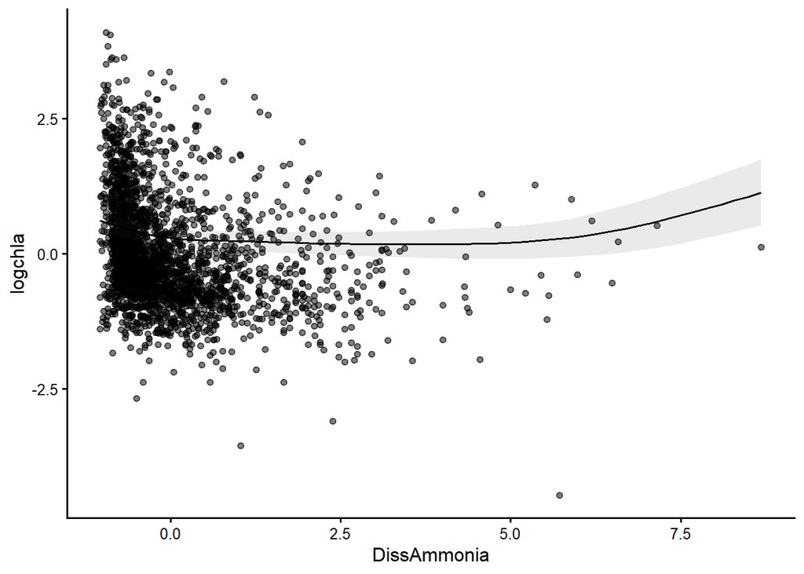

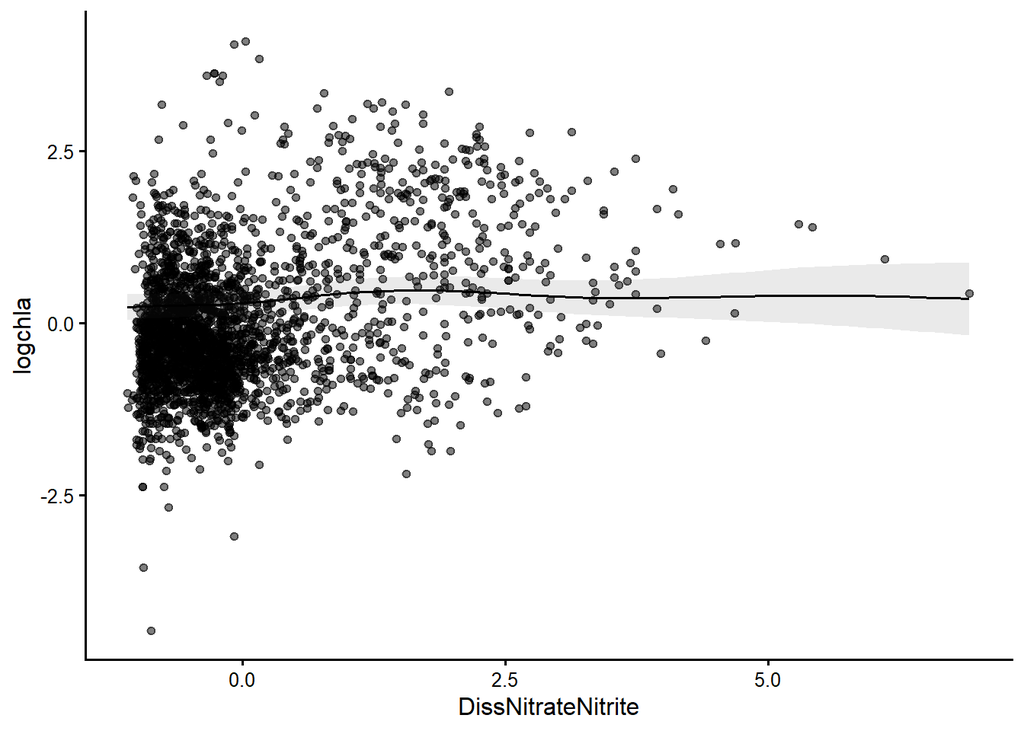

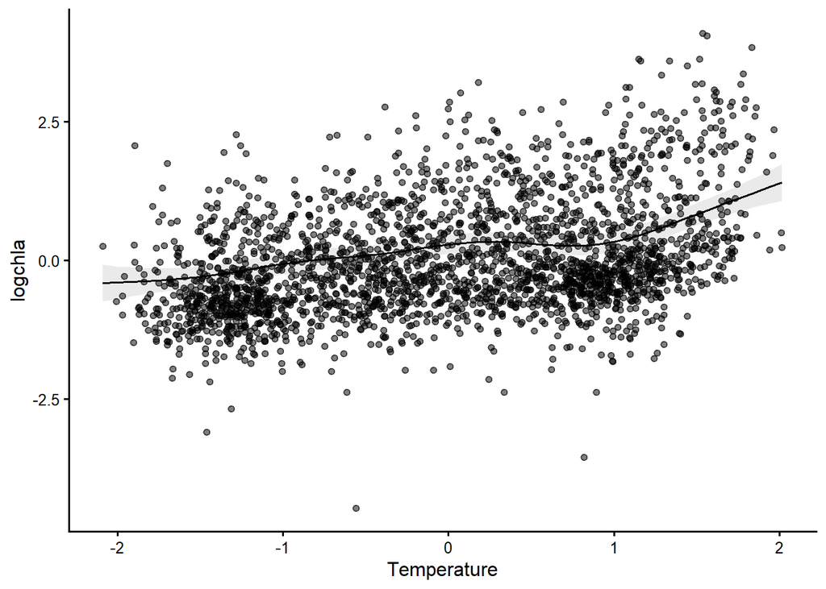

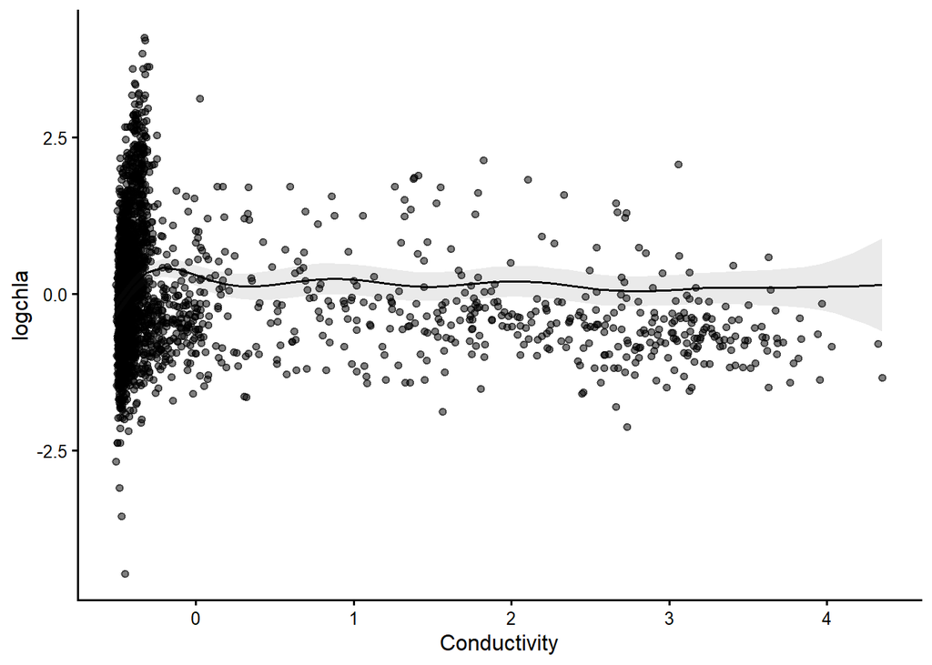

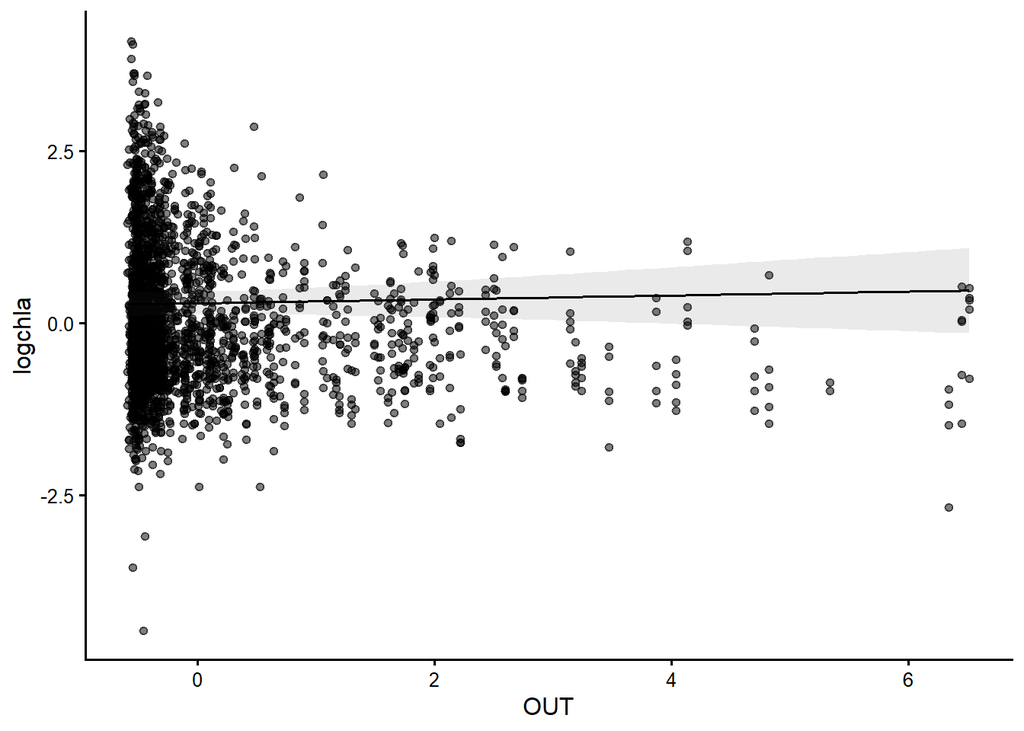

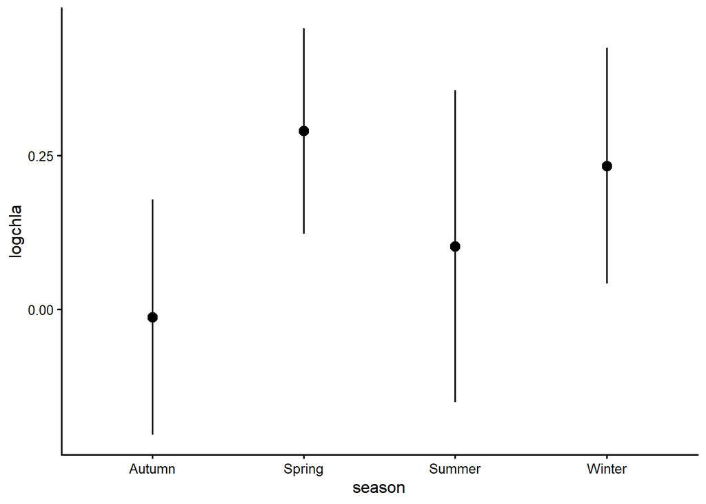

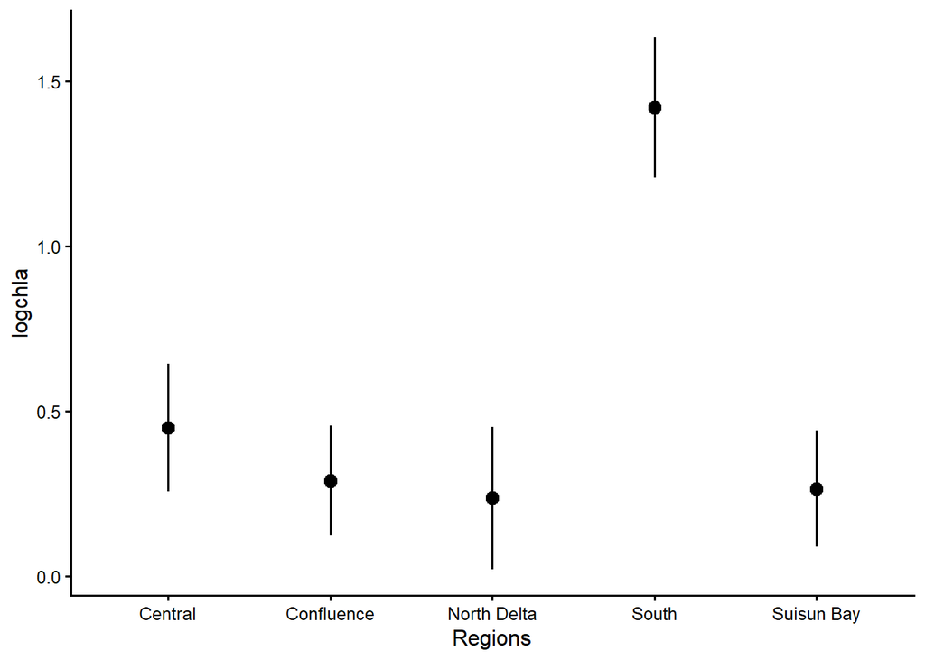

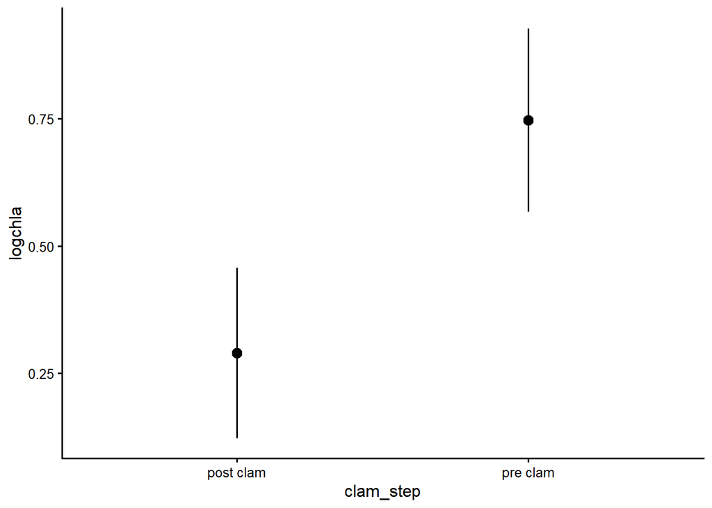

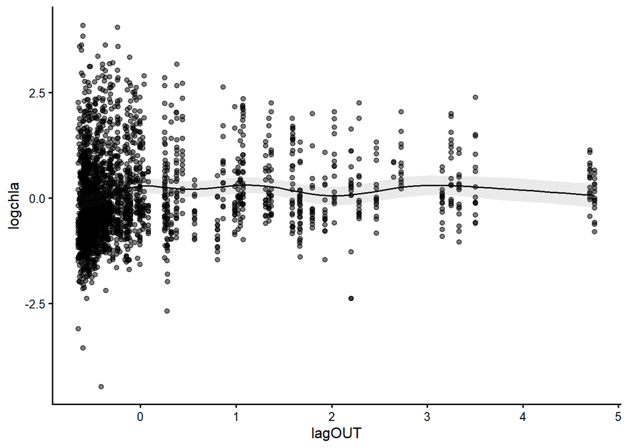

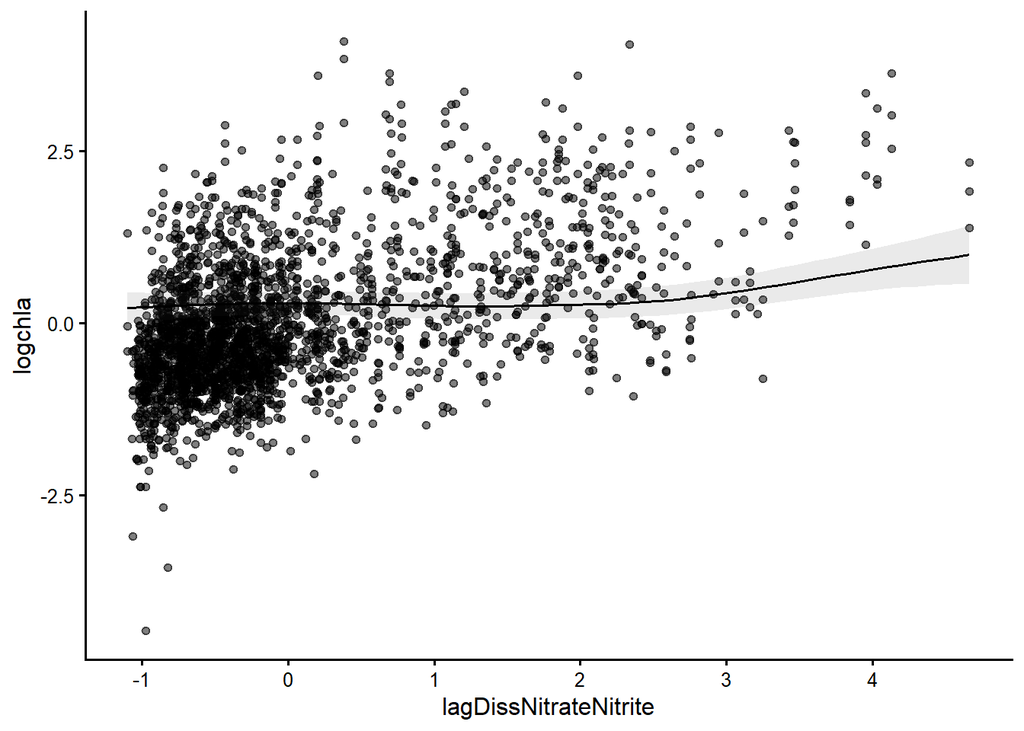

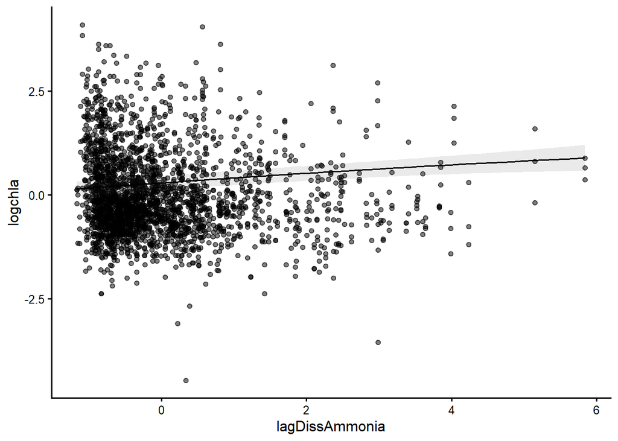

```r
c <- c("DissAmmonia",
          "DissNitrateNitrite",
          "Temperature",
          "Conductivity",
          "OUT",
          "season",
          "Regions",
          "clam_step",
          "lagOUT",
          "lagDissNitrateNitrite",
          "lagDissAmmonia")

lapply(c, function(x) {
  plot_predictions(m3.shrink, x , points = .5) +
    theme_classic(base_size = 12)
})
```

### marginal effects

The marginal effects in this plot can be interpreted as measuring the change in Y that is associated with a small increase in X, for different baseline values of X.

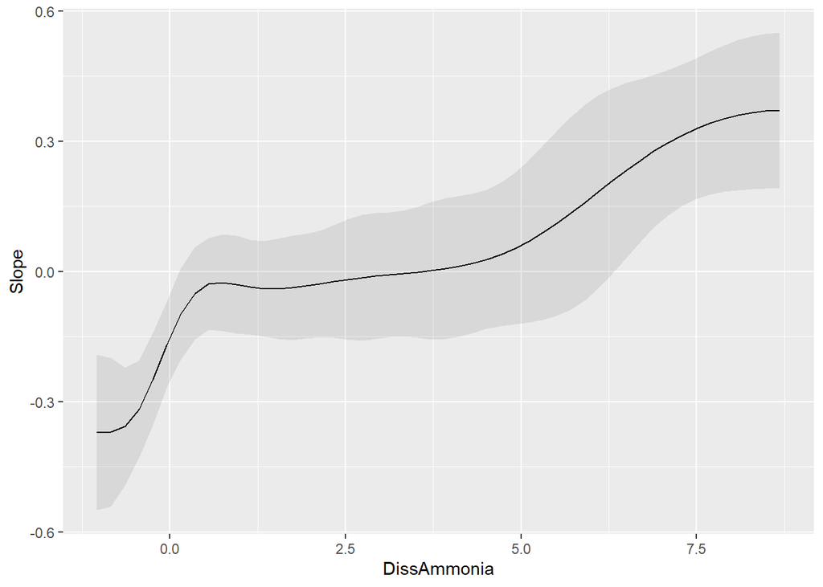

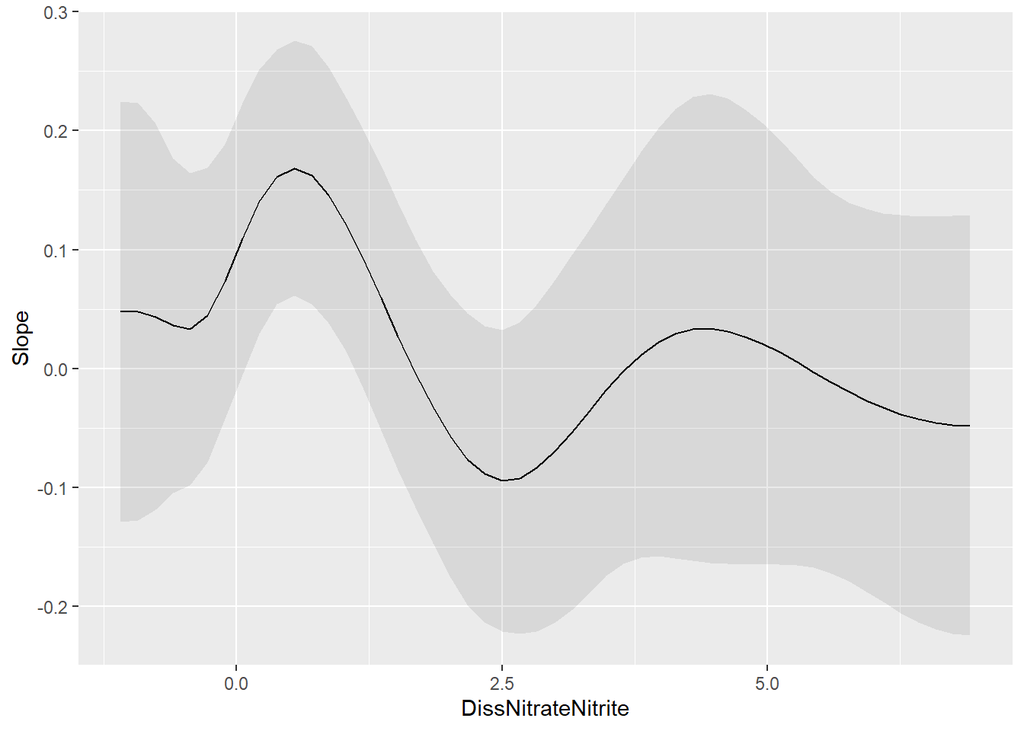

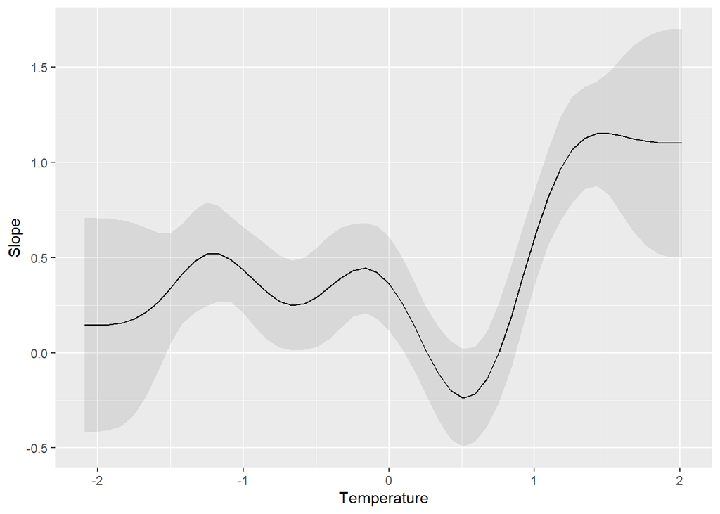

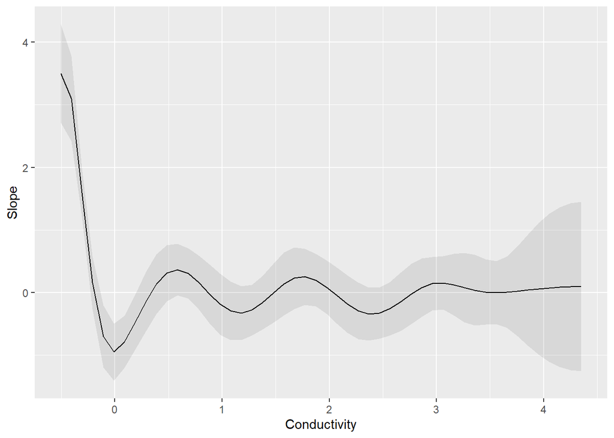

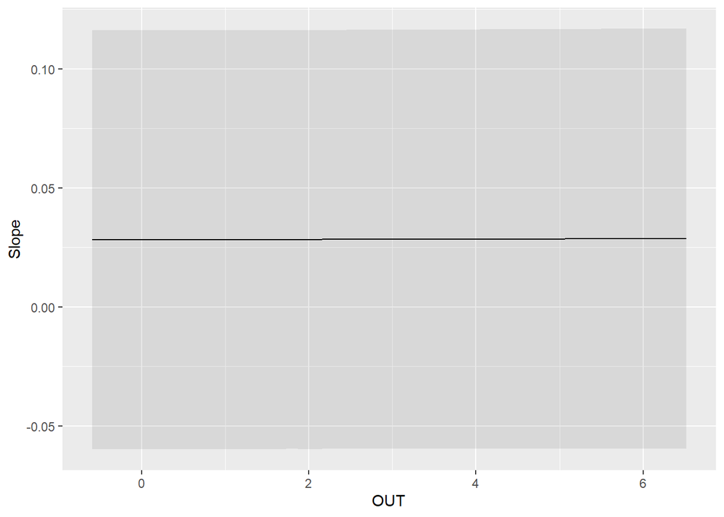

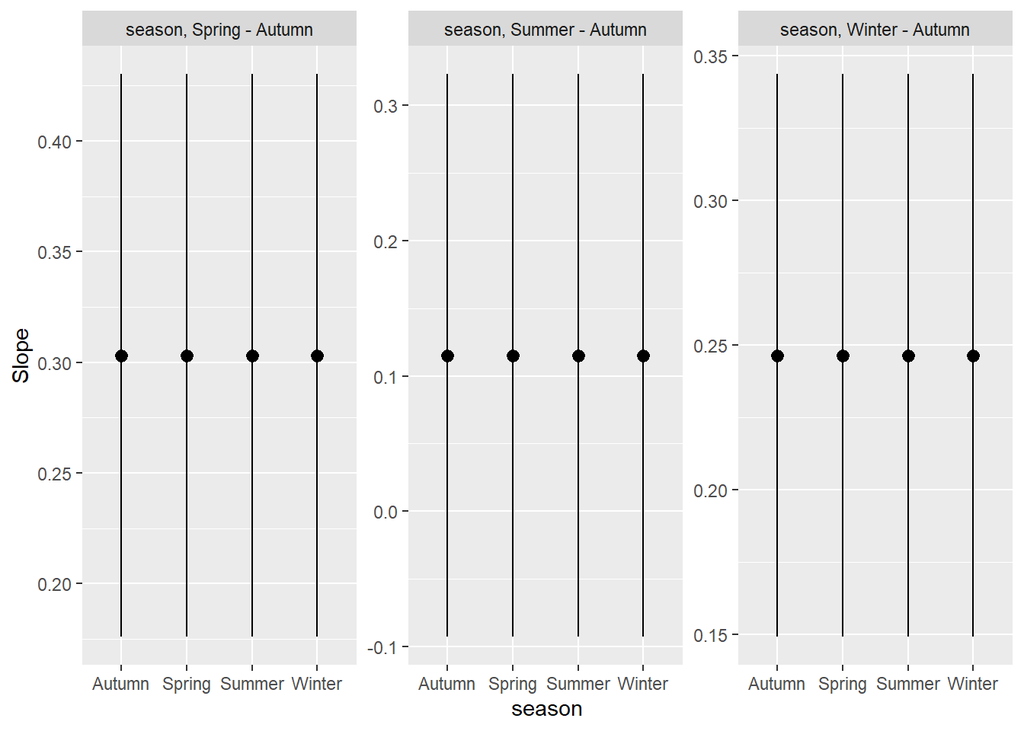

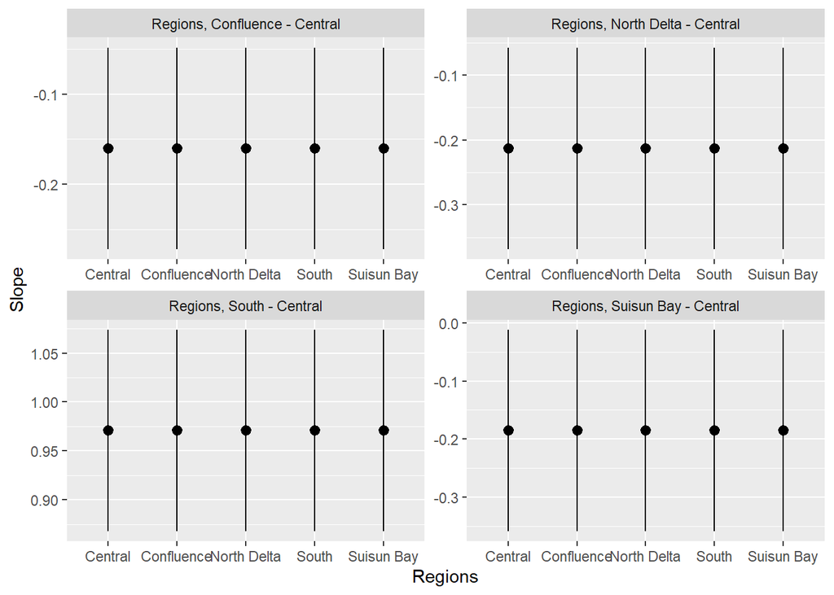

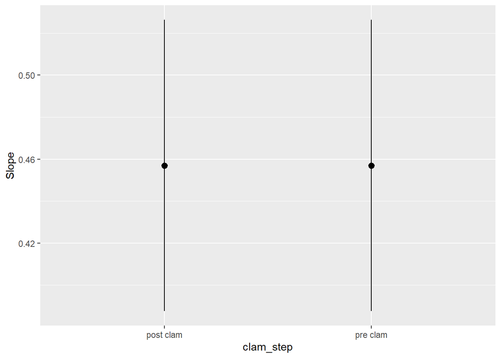

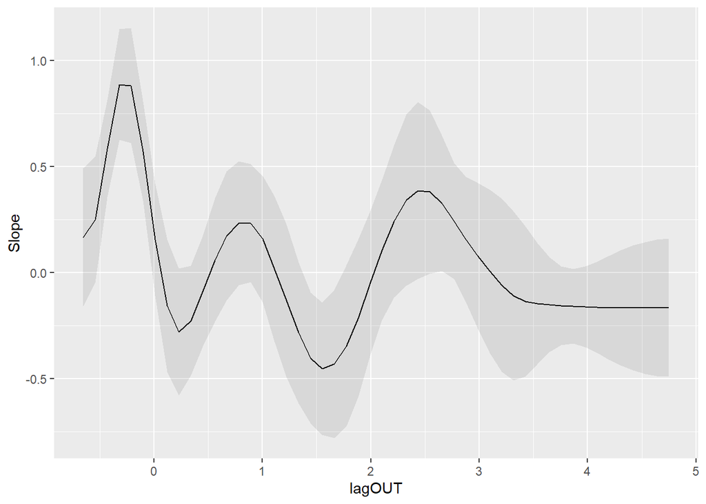

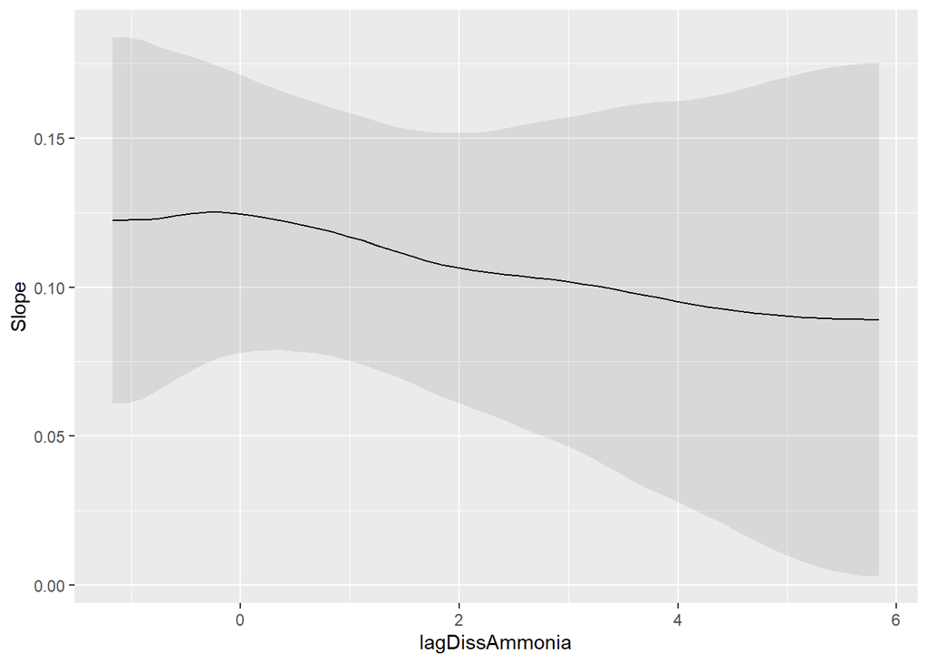

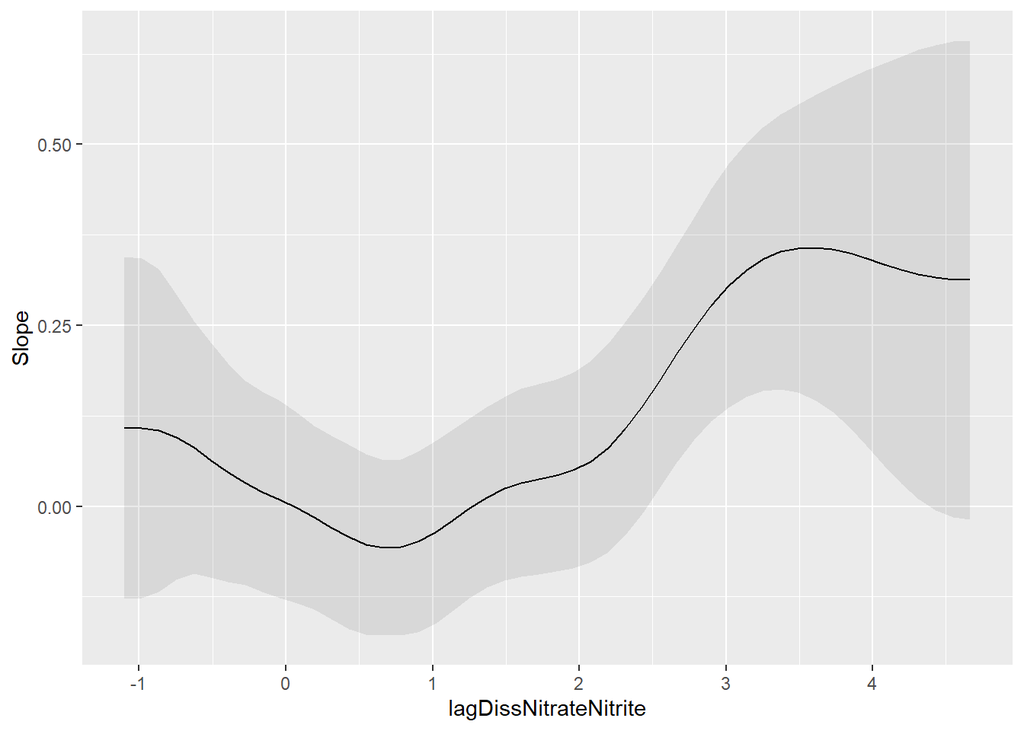

```r
c <- c("DissAmmonia",
          "DissNitrateNitrite",
          "Temperature",
          "Conductivity",
          "OUT",
          "season",
          "Regions",
          "clam_step",
          "lagOUT",
          "lagDissAmmonia",
          "lagDissNitrateNitrite")

lapply(c, function(x) {
  plot_slopes(m3.shrink, variables = x, condition = x)
})
```

### diagnostics

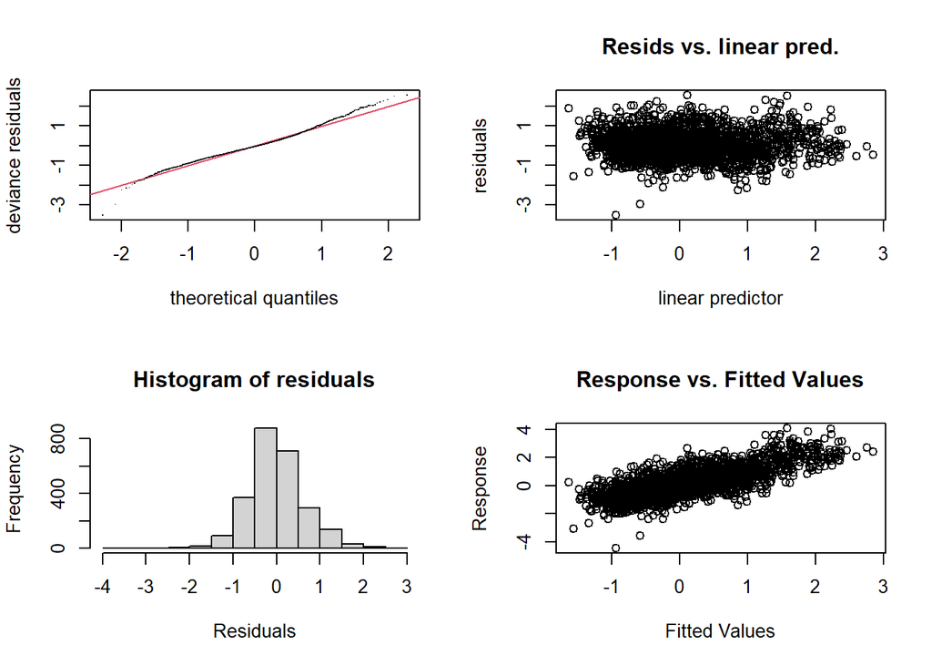

```
##
## Method: ML   Optimizer: outer newton
## full convergence after 18 iterations.
## Gradient range [-0.001401024,0.005541366]
## (score 2562.697 & scale 0.4130036).
## Hessian positive definite, eigenvalue range [2.300012e-05,1274.034].
## Model rank =  86 / 86
##
## Basis dimension (k) checking results. Low p-value (k-index<1) may
## indicate that k is too low, especially if edf is close to k'.
##
##                               k'     edf k-index p-value
## s(DissAmmonia)           9.00000 4.22435      NA      NA
## s(DissNitrateNitrite)    9.00000 3.42522      NA      NA
## s(Temperature)           9.00000 6.64842      NA      NA
## s(Conductivity)          9.00000 8.32338      NA      NA
## s(OUT)                   9.00000 0.00359      NA      NA
## s(Regions)               5.00000 3.93902      NA      NA
## s(lagOUT)                9.00000 6.61806      NA      NA
## s(lagDissAmmonia)        9.00000 1.40025      NA      NA
## s(lagDissNitrateNitrite) 9.00000 3.75233      NA      NA
```

```r
gam.check(m3.shrink)
```

## m4

- gam((logchla) ~ s(DissAmmonia) + s(DissNitrateNitrite) + s(Temperature) + s(Conductivity, k=12) + s(SAC) + s(Regions, bs=‘re’) + season + (SAC*season) + clam_step + s(lagSAC) + s(lagDissAmmonia)

### concurvity

<0.3 - low, >0.5 - some concern, >0.8 - very high

```r
concurvity(m4.shrink)
```

```
##          para s(DissAmmonia) s(DissNitrateNitrite) s(Temperature)
## worst       1      0.5409353             0.7905432      0.8208171
## observed    1      0.5132702             0.6297380      0.6673556
## estimate    1      0.2112056             0.3698569      0.7250455
##          s(Conductivity)    s(SAC) s(Regions) s(lagSAC) s(lagDissAmmonia)
## worst          0.8585533 1.0000000  1.0000000 0.7528281         0.5827566
## observed       0.5671797 0.7145348  0.6743210 0.5528421         0.5033923
## estimate       0.5597767 0.8541385  0.6631919 0.6707153         0.2895704
```

Print predictor combinations with worst-case index of concurvity >0.5

```r
w <- concurvity(m4.shrink, full =FALSE)
wdf<- as.data.frame(w$worst)
i <- which(wdf > 0.5, arr.ind = TRUE)
r <- data.frame(
  Row = rownames(wdf)[i[, 1]],
  Column = colnames(wdf)[i[, 2]],
  Value = wdf[i]
)
r <- r[r$Row != r$Column, ]
r
```

|  | Row | Column | Value |
| --- | --- | --- | --- |
| 2 | s(Regions) | para | 1.0000000 |
| 5 | s(Regions) | s(DissNitrateNitrite) | 0.5971421 |
| 8 | s(Regions) | s(Conductivity) | 0.7778515 |
| 10 | para | s(Regions) | 1.0000000 |
| 11 | s(DissNitrateNitrite) | s(Regions) | 0.5971421 |
| 12 | s(Conductivity) | s(Regions) | 0.7778515 |

### VIF

```r
m.l<- lm(formula = logchla ~ SAC + clam_step,
            data=df)
vif(m.l)
```

```
##       SAC clam_step
##  1.020423  1.020423
```